# Chapter 5

The confrontation: Sum of Squares

JC

Wed Jul 11 15:29:10 2018

# The system

We start by assuming a process model (the signal) of the form:

$$Y_i = A + BX_i + CX_i^2 + W_i$$

Where $W_i$ represents the process ucnertainty, while $A$, $B$, and $C$ are parameters. Our objective is to esitimate these parameters, which we denote $A_{est}$, $B_{est}$, and $C_{est}$, such that $T_{pre,i} = A_{est} + B_{est}X_i + C_{est}X_i^2$

## Pseudocode 5.2

I will create a function for our process equation:

```r
process <- function(x = c(1:50), A = 10, B = 20, C = 30, sd = 0){
  y <- A + B*x + C*x^2 + rnorm(n = length(x), mean = 0, sd = sd)
  return(y)
}
```

## Visualize the process and associated error

```r
suppressPackageStartupMessages({
  library(tidyverse)
})
```

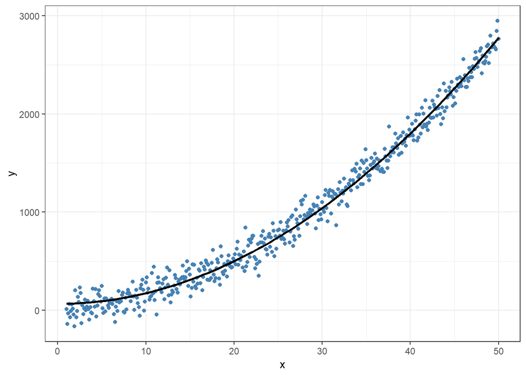

```r
#Define a vector of X
x <- seq(from = 1, to = 50, by = 0.1)

# Define known parameters
A <- 10
B <- 5
C <- 1
sd <- mean(process(x = x, A = A, B = B, C = C)) / 10

set.seed(43)

tibble(x) %>%
  mutate(y = process(x = x, A = A, B = B, C = C, sd = sd)) %>%
  ggplot(aes(x = x, y = y)) +
  geom_point(color = "steelblue") +
  geom_smooth(method = "lm", formula = y~I(x^2), color = "black") +
  theme_bw()
```

# Sum of squares

The sum of squares is defined as:

$$\sum_{i = 1}^n(Y_{pre,i} - Y{obs, i})^2$$

Which can be rewritten as a function of $A_{est}$, $B_{est}$, and $C_{est}$ as:

$$\gamma(A_{est}, B_{est}, C_{est}) = \sum_{i = 1}^n(A_{est} + B_{est}X_i + C_{est}X_i^2 - Y{obs, i})^2$$

The goal is to obtain the best combination of $A_{est}$, $B_{est}$, and $C_{est}$ to minimize $\gamma(A_{est}, B_{est}, C_{est})$. The minimum of the equation above is given found where the three partial derivatives = 0. The partial derivatives are:

$$\begin{split}
\frac{\partial\gamma}{\partial A_{est}} = \sum_{i = 1}^n 2(A_{est} + B_{est}X_i + C_{est}X_i^2 - Y{obs, i})\\
\frac{\partial\gamma}{\partial B_{est}} = \sum_{i = 1}^n 2X_i(A_{est} + B_{est}X_i + C_{est}X_i^2 - Y{obs, i})\\
\frac{\partial\gamma}{\partial C_{est}} = \sum_{i = 1}^n 2X_i^2(A_{est} + B_{est}X_i + C_{est}X_i^2 - Y{obs, i})
\end{split}$$

We can either solve these system of linear equations, or search for all possible parameters until we reach the optimum values.

## Function to calculate SS

Now let’s create a function that calculates the sum of squares given two inputs (observed and predicted):

```r
sum_squares <- function(pred = NULL, obs = NULL){
  stopifnot(exprs = {
    !is.null(pred)
    !is.null(obs)
  })
  sum((pred-obs)^2)
}
```

# Obtain parameters

## Pseudocode 5.1

(modified to use `for` loop instead of `while` or `until` control sequences)

I know what the true parameters are (see above), so I can try and estimate these parameters by searching the parameter space in a very inefficient way with for loops. I wil create a function for that:

```r
get_params <- function(x, y_obs, min = c(0, 0, 0), max = c(50, 10, 5), steps = NULL, prec = 10, verbose = T){
  Amin <- min[1]
  Amax <- max[1]
  Bmin <- min[2]
  Bmax <- max[2]
  Cmin <- min[3]
  Cmax <- max[3]

  stepsA <- (Amax - Amin) / prec
  stepsB <- (Bmax - Bmin) / prec
  stepsC <- (Cmax - Cmin) / prec

  As <- seq(Amin, Amax, by = stepsA)
  Bs <- seq(Bmin, Bmax, by = stepsB)
  Cs <- seq(Cmin, Cmax, by = stepsC)

  gamma <- array(data = NA,
                 dim = c(length(As),
                         length(Bs),
                         length(Cs)))

  for(a in 1:length(As)){
    A_est <- As[a]
    for(b in 1:length(Bs)){
      B_est <- Bs[b]
      for(c in 1:length(Cs)){
        C_est <- Cs[c]
        y_pred <- process(x = x, A = A_est, B = B_est, C = C_est, sd = 0)
        gamma[a, b, c] <- sum_squares(pred = y_pred, obs = y_obs)

      }
    }
  }
    best_fit <- which(gamma == min(gamma), arr.ind = TRUE)

    params <- c(As[best_fit[1]],
                Bs[best_fit[2]],
                Cs[best_fit[3]])

    if(verbose){print(paste0("Minimum SS = ",min(gamma),
                            "with parameters: A = ", params[1],
                            ", B =", params[2],
                            ", and C = ", params[3]))}

    return(params)
}
```

I can now use the three functions defined above to obtain the parameters that minimize the sum of squares, given a precision that I am willing to use. Remember there is a tradeoff between precission and computation time.

```r
set.seed(43)
y_obs <- process(x = x, A = A, B = B, C = C, sd = sd)

start1 <- Sys.time()

params <- get_params(x = x, y_obs = y_obs, min = c(5, 2, 0), max = c(15, 7, 2), prec = 50)
```

```
## [1] "Minimum SS = 4651449.69233504with parameters: A = 15, B =4.8, and C = 1"
```

```r
end1 <- Sys.time()
```

Let’s plot the fit

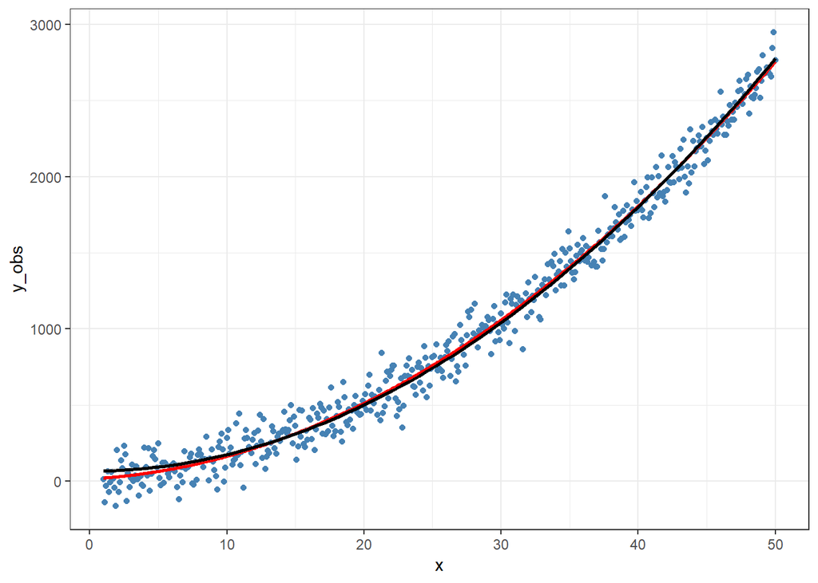

```r
tibble(x, y_obs) %>%
  mutate(y_pred = process(x = x, A = params[1], B = params[2], C = params[3], sd = 0)) %>%
  ggplot() +
  geom_point(aes(x = x, y = y_obs), color = "steelblue") +
  geom_line(aes(x = x, y = y_pred), color = "red", size = 1) +
  geom_smooth(aes(x = x, y = y_obs), method = "lm", formula = y~I(x^2), color = "black") +
  theme_bw()
```

## `tidy` approach

I used a `for` loop before, which is not very efficient. Let’s see if I can do better witha tidy approach:

```r
# I create vectors similar to the ones created within get_params()
As <- seq(5, 15, by = 0.2)
Bs <- seq(2, 7, by = 0.1)
Cs <- seq(0, 2, by = 0.04)

start2 <- Sys.time()
results <- expand.grid(As, Bs, Cs) %>%
  magrittr::set_colnames(value = LETTERS[1:3]) %>%
  mutate(x = list(x),
         obs = list(y_obs),
         pred = pmap(.l = list(x = x, A = A, B = B, C = C), .f = process),
         ss = pmap_dbl(.l = list(pred = pred, obs = obs), .f = sum_squares)) %>%
  select(A, B, C, ss)
end2 <- Sys.time()

results2 <- results %>%
  filter(ss == min(ss))

results2
```

```
##    A   B C      ss
## 1 15 4.8 1 4651450
```

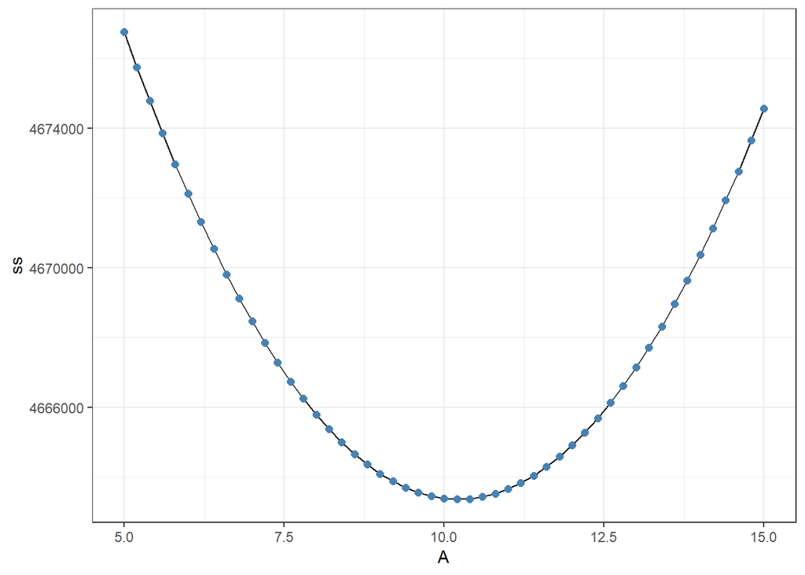

```r
results %>%
  filter(B == 5, C == 1) %>%
  ggplot(aes(x = A, y = ss)) +
  geom_line() +
  geom_point(color = "steelblue", size = 2) +
  theme_bw()
```

This approach uses much less code, and it’s a bit more self-evident (I think). It’s about as slow for now, but when scaling up by increasing the precision it is faster 12.5963418, 14.4034228.

# `lm` approach

Finally, the logical approach is to just fit the model with `lm`:

```r
model <- lm(y_obs ~ x + I(x^2))

stargazer::stargazer(model, type = "html", intercept.bottom = F, single.row = T)
```

|  | *Dependent variable:* |
| --- | --- |
|  | y_obs |
| Constant | 17.033 (14.263) |
| x | 4.991*** (1.288) |
| I(x2) | 0.992*** (0.025) |
| Observations | 491 |
| R<sup>2</sup> | 0.986 |
| Adjusted R<sup>2</sup> | 0.986 |
| Residual Std. Error | 97.577 (df = 488) |
| F Statistic | 16,831.330*** (df = 2; 488) |
| *Note:* | p<0.1; p<0.05; p<0.01 |

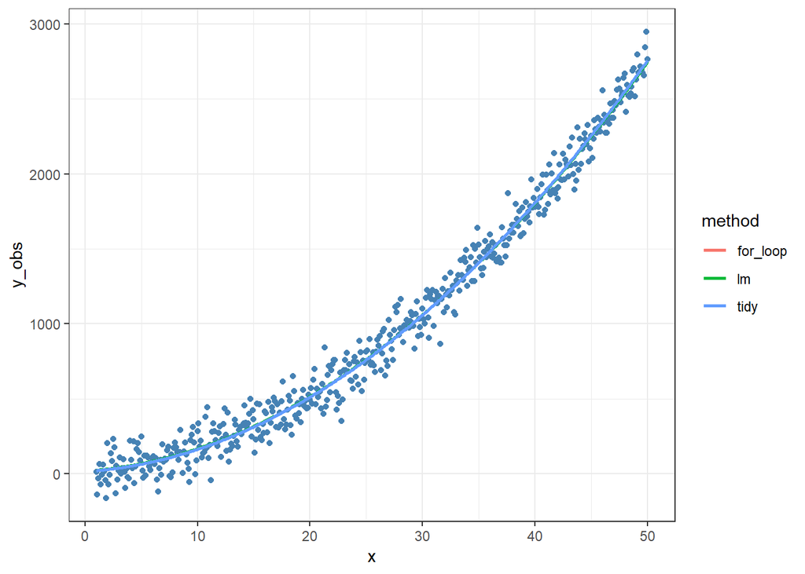

```r
tibble(x, y_obs) %>%
  mutate(for_loop = process(x = x, A = params[1], B = params[2], C = params[3], sd = 0),
         tidy = process(x = x, A = results2$A, B = results2$B, C = results2$C, sd = 0),
         lm = predict(model)) %>%
  gather(method, value, -c(x, y_obs)) %>%
  ggplot() +
  geom_point(aes(x = x, y = y_obs), color = "steelblue") +
  geom_line(aes(x = x, y = value, color = method), size = 1) +
  theme_bw()
```

We can also check the fitted vs predicted plots

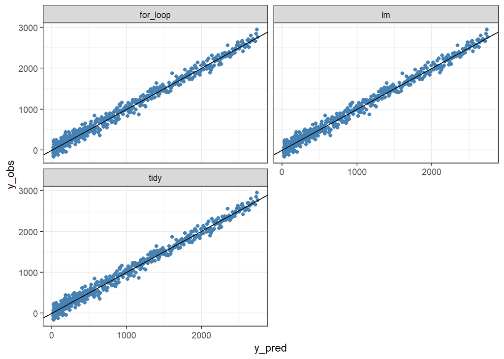

```r
tibble(x, y_obs) %>%
  mutate(for_loop = process(x = x, A = params[1], B = params[2], C = params[3], sd = 0),
         tidy = process(x = x, A = results2$A, B = results2$B, C = results2$C, sd = 0),
         lm = predict(model)) %>%
  gather(method, y_pred, -c(x, y_obs)) %>%
  ggplot() +
  geom_point(aes(x = y_pred, y = y_obs), color = "steelblue") +
  facet_wrap(~method, ncol = 2) +
  geom_abline(slope = 1) +
  theme_bw()
```